# Final Paper - Myopia Control

Ahmed_Drammeh

5/8/2021

## Context

The development of an eye towards **myopia** falls under the category known as emmetropization. This process is guided by visual input, and the mechanisms that coordinate this process are not fully understood. It is assumed that emmetropization occurs via an active mechanism by which defocus drives growth of the eye, and that genetic factors and emmetropization both influence the growth of the eye’s axis. It has long been assumed that wearing corrective spectacles might possibly hinder the process of emmetropization in young children, and this assumption has being supported in particular by animal studies. However, undercorrection of myopia in humans has been shown to increase the rate of myopic progression.[@shao2015optical]. There has been some research on causal factors involved in the development of myopia. In particular, **statistics show that prolonged near work correlates with the development of myopia**, but it is still unclear whether a causal relationship exists. There are many hypotheses out there which explain the nature and onset and constant evolution of myopia, and one in particular deals with defocusing of the periphery(using micron scale sized lenses on the periphery of a regular spectacle lens). There are some known solutions to retard the progression of myopia in children, but all of them appear to be quite invasive in nature. **This paper’s focus, is on analyzing experimental data generated from a potential technological non-invasive (spectacle lenses with microlenses) solution to retard and or eliminate myopic progression in children**. The dataset is produced via a lens fabricating technology called injection molding.

## Introduction

The dataset below describes optical measurements of an Injection molded lenses called **Shark**. This spectacle lens is generated by a process called injection molding lithography, which is a replication technique in the manufacturing industry. Any stamp/substrate with fine micro-details engraved/embossed within the surface can be replicated using said technology.The replicated Shark lenses include various characteristics such as front Diopter (describes the base curvature of the front of the lens), radius, cylinder and refractive index. The goal of this report is to evaluate whether or not different molding conditions used during lens generation, will have an impact on the measured global power for the microlenses. Furthermore, the study includes three different grades of Polycarbonate(PC) resin and two types of CNC steel manufactured insert designs **(D19121901 & D_26012101)**, which have different geometric dimensions to alter the optical performance of the final product. The analysis for this paper will focus solely on **D26012101.**

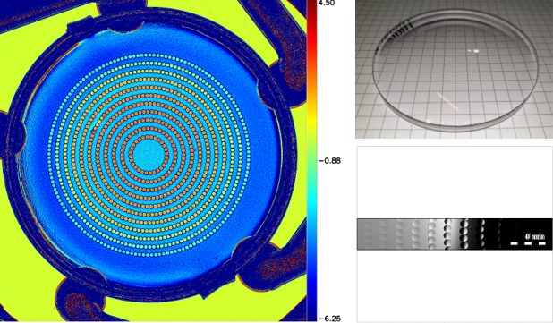

##### Figure 1: *Spectacle lens with 11 concentric rings around the pheripery*

#### Material candidates:

- MEP grade: *CLV1000* - High viscosity( low flow rate resin)
- MEP grade: *CLV4400* - Low viscosity( high flow rate resin)
- Sabic grade: *OQ1022* - Medium viscosity(medium flow rate resin)
- **30 lids from each grade were molded ( x 6 process conditions)**
- **15 lids from each process condition were, *PRE.DRIED* @ 120C, to assess impact of drying on the final results.**

## Experimental Approach

After a comprehensive recording of several important molding variables such as *Lid (center)CT thickness*, *Fill-time*, *Injection-Pressure*, *Pack+Hold-time*, subsequent optical measurements were also performed after Injection Molding, and these included two key output variables namely *SR2-Optics* and *Jarvis Clearreader*. SR2 optics provides the **cylinder** of a spectacle lens, which is important in vision correction. These variables alongside many others were recorded on a spreadsheet and analyzed to determine whether certain trends can be observed which may point towards good product quality, or whether inferences can be made to inform future processing strategies.

The analysis will take a close look at the optical measurements from the *Jarvis Clear-reader* and see if the microlenses optical performance have any correlation between the various material candidates and their respective process conditioning. The methodology that will be employed in the analyses portion of this paper will include looking at box-plot, scatter plots and histograms as a descriptive tool to make sense of the data. Variables from the Jarvis will mainly highlight the *Global Power Average* for each microlens spanning Rings 1 -11. and relationships between *drying vs non-drying* will be looked at aswell as changes in processing condition. The *Global Power Average* which is the indicator of the effectiveness of the lens to correct vision, will be compared to the design specification to see if the injection molding process can successfully replicate the microlenses and maintain its optical power profile. The dataset can be cumbersome and tedious, but R tidying & cleaning strategies will be utilized to navigate and capture key parts of the data of interest.

## Data Cleaning

```r
Shark<-read.csv("Shark_Encap-PMMA_Over_Mold_V4.csv", stringsAsFactors = FALSE,skip=2, header=TRUE)
dim(Shark)
```

```
## [1] 324  39
```

```r
str(Shark)
```

```
## 'data.frame':    324 obs. of  39 variables:
##  $ Date                      : chr  "2/6/2021" "" "" "" ...
##  $ Sample.ID                 : chr  "A16" "A17" "A18" "A19" ...
##  $ CT..mm.                   : chr  "1.16" "1.16" "1.16" "1.16" ...
##  $ PRE.DRY                   : chr  "CLV1000-No" "CLV1000-No" "CLV1000-No" "CLV1000-No" ...
##  $ Mold                      : chr  "R&D 2-Cav" "R&D 2-Cav" "R&D 2-Cav" "R&D 2-Cav" ...
##  $ A.SIDE                    : int  217 217 217 217 217 217 217 217 217 217 ...
##  $ B.SIDE                    : int  220 220 220 220 220 220 220 220 220 220 ...
##  $ A.SIDE.1                  : int  195 195 195 195 195 195 195 195 195 195 ...
##  $ B.SIDE.1                  : int  200 200 200 200 200 200 200 200 200 200 ...
##  $ Melt.Temp..F.             : int  460 460 460 460 460 460 460 460 460 460 ...
##  $ Fill.time..s.             : num  6.52 6.52 6.52 6.53 6.53 6.56 6.56 6.55 6.55 6.52 ...
##  $ Cooling.time              : int  325 325 325 325 325 325 325 325 325 325 ...
##  $ X1st....                  : num  5 5 5 5 5 5 5 5 5 5 ...
##  $ X2nd....                  : chr  "12" "12" "12" "12" ...
```

[output cut: 25 more lines]

```r
## Switching from character to numeric to setup data visualization
Shark$R.01<-as.numeric(as.character(gsub(",", "",Shark$R.01)))
Shark$R.04<-as.numeric(as.character(gsub(",", "",Shark$R.04)))
Shark$CT..mm.<-as.numeric(as.character(gsub(",", "",Shark$CT..mm.)))
Shark$Diopter.3.5...0.06<-as.numeric(as.character(gsub(",", "",Shark$Diopter.3.5...0.06)))
Shark$Cyl...0.06.<-as.numeric(as.character(gsub(",", "",Shark$Cyl...0.06.)))
Shark$X<-NULL
## Selecting specific rows of interest involved in the analysis. This includes cylinder (Cyl), Rings 1-11, PRE.DRY and Power Average.
library(tidyverse)
Shark1<-select(Shark,4:5, 26:38)
```

## Data Tidying & Visualization

After the initial data cleaning step, it was vital to look at some descriptive statistics of the data and see if trends can be identified. In this data, it was important to shift the data from wide to long format, to be able to compare the variables accurately. Below are some of the visualizations that were used to help guide in the understanding of one/more response variables (global Power average, Cylinder) with respect to input variables(Resin grade, drying…etc). Most of the initial visualizations focused on expected trends and behaviors, aswell as trends to help consolidate the data further.

```r
library(ggplot2)
library(tidyverse)
library(tidyr)
library(dplyr)
Shark.tidy<-gather(Shark1, key="Ring", value="Global_Power_Avg", -1,-2,-3,-4, na.rm=TRUE)
head(Shark.tidy)
```

|  | PRE.DRY | Mold | Cyl...0.06. | Insert..Design | Ring | Global_Power_Avg |
| --- | --- | --- | --- | --- | --- | --- |
| 1 | CLV1000-No | R&D 2-Cav | 0.02 | D_19121901 | R.01 | 3.577 |
| 3 | CLV1000-No | R&D 2-Cav | 0.03 | D_19121901 | R.01 | 3.547 |
| 4 | CLV1000-No | R&D 2-Cav | 0.02 | D_19121901 | R.01 | 3.438 |
| 5 | CLV1000-No | R&D 2-Cav | 0.02 | D_19121901 | R.01 | 3.513 |
| 6 | CLV1000-No | R&D 2-Cav | 0.02 | D_19121901 | R.01 | 3.493 |
| 7 | CLV1000-No | R&D 2-Cav | 0.02 | D_19121901 | R.01 | 3.546 |

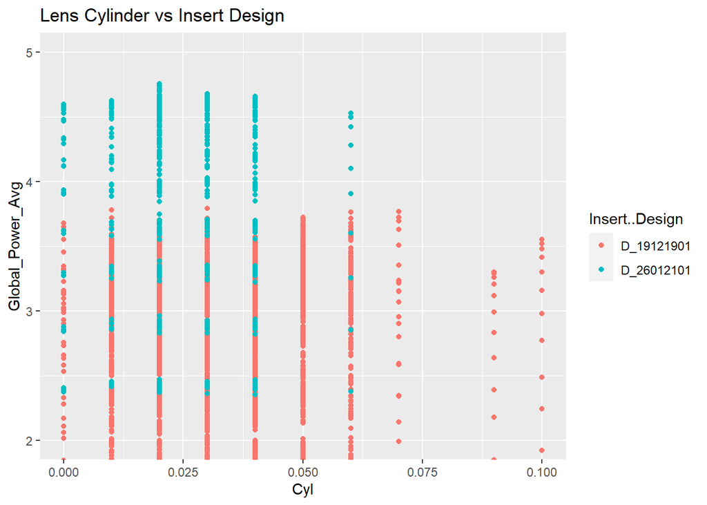

```r
## Some expected relationships. Insert design D26012101 has a higher power. (Global Power average > D19....)
Shark.tidy %>%
  mutate(Cyl = Cyl...0.06.) %>%
  ggplot(aes(x=Cyl, y=Global_Power_Avg, color=Insert..Design)) + geom_point() + coord_cartesian(ylim=c(2,5)) +ggtitle("Lens Cylinder vs Insert Design")
```

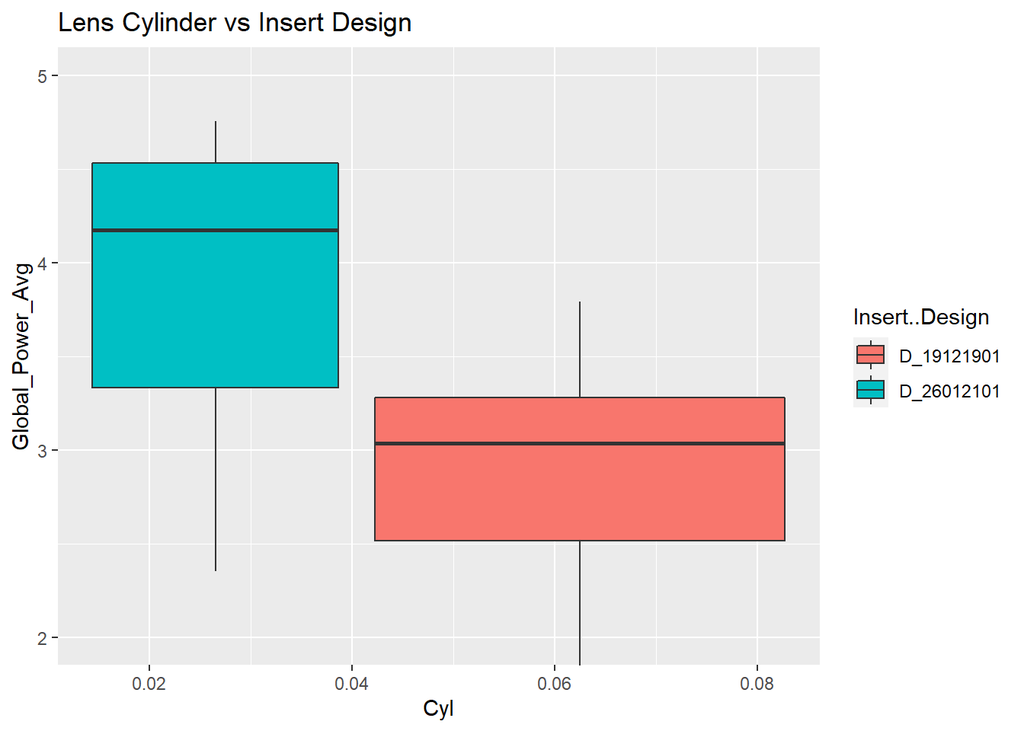

```r
Shark.tidy %>%
  mutate(Cyl = Cyl...0.06.) %>%
  ggplot(aes(y =Global_Power_Avg, x=Cyl, fill=Insert..Design)) + geom_boxplot() + ggtitle("Lens Cylinder vs Insert Design") + coord_cartesian(ylim=c(2,5))
```

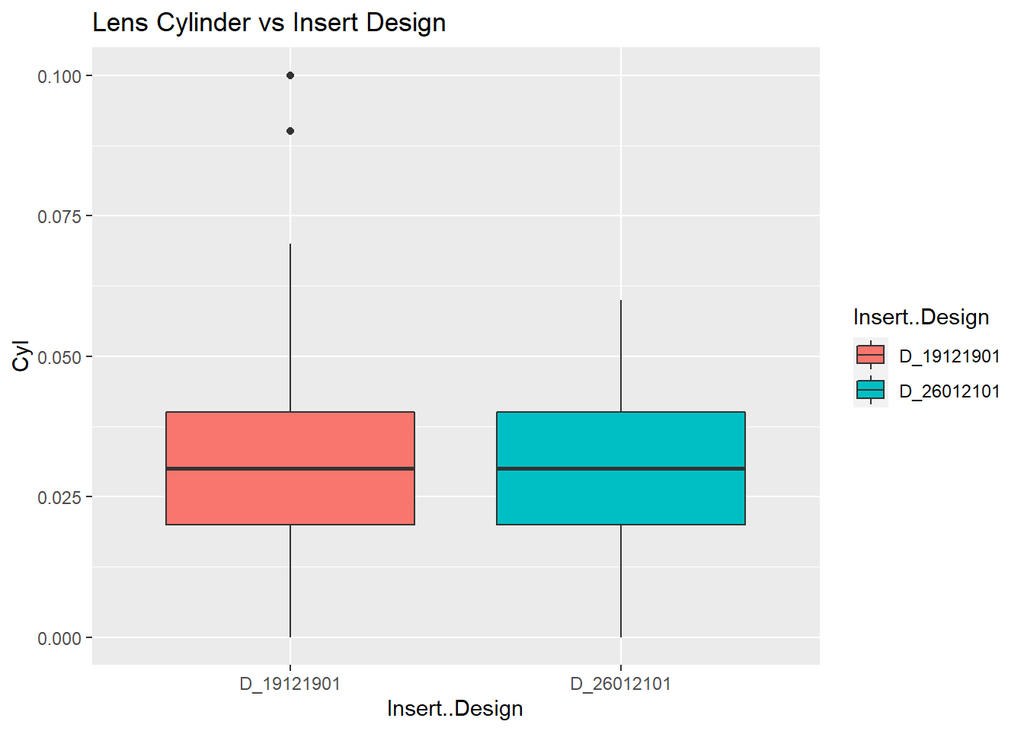

```r
## No influence on lens cylinder based on Insert design.
Shark.tidy %>%
  mutate(Cyl = Cyl...0.06.) %>%
  ggplot(aes(x =Insert..Design, y=Cyl, fill=Insert..Design)) + geom_boxplot() + ggtitle("Lens Cylinder vs Insert Design")
```

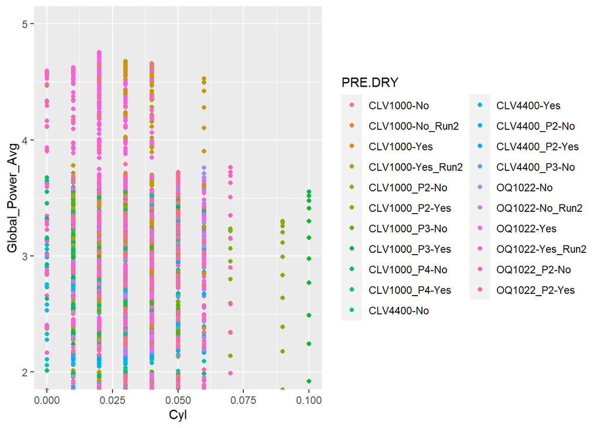

```r
## There Should be no influence between Cylinder vs Global Power average when it comes to Resin grade
Shark.tidy %>%
  mutate(Cyl = Cyl...0.06.) %>%
  ggplot(aes(x=Cyl, y=Global_Power_Avg, color=PRE.DRY)) + geom_point() + coord_cartesian(ylim=c(2,5))
```

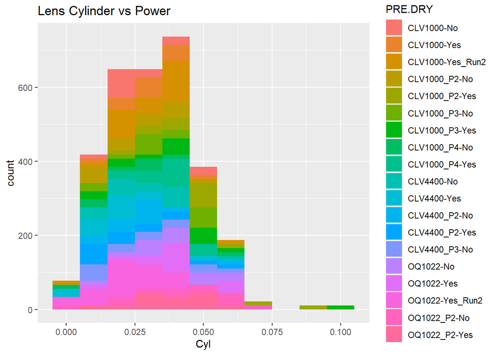

```r
Shark.tidy %>%
  mutate(Cyl = Cyl...0.06.) %>%
  ggplot(aes(x=Cyl, fill=PRE.DRY)) + geom_histogram(binwidth = 0.01) + ggtitle("Lens Cylinder vs Power")
```

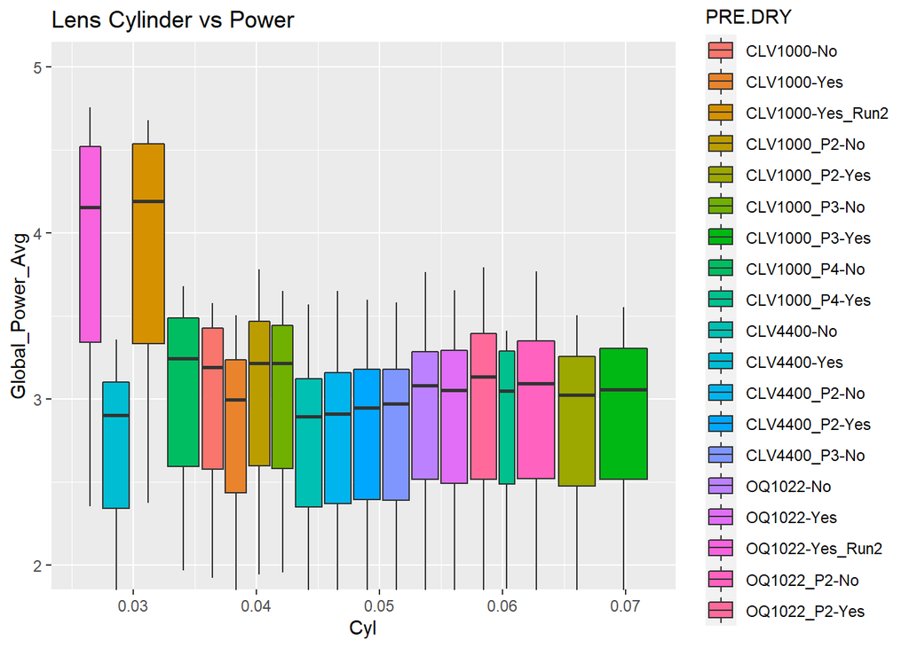

```r
Shark.tidy %>%
  mutate(Cyl = Cyl...0.06.) %>%
  ggplot(aes(x=Cyl, y=Global_Power_Avg, fill=PRE.DRY)) + geom_boxplot() + coord_cartesian(ylim=c(2,5)) + ggtitle("Lens Cylinder vs Power")
```

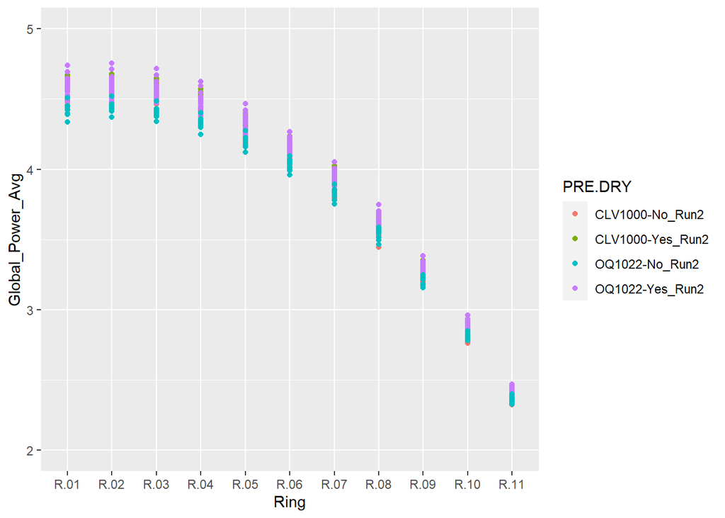

```r
## USing filter() to selectively focus on the Insert design (D26012101) we hinted on, in the experimental approach section.
Shark_tidy1<-filter(Shark.tidy, Insert..Design=="D_26012101")%>% mutate(Cyl...0.06.=NULL)
## CLV1000 Resin grade visualization

ggplot(Shark_tidy1,aes(y=Global_Power_Avg, x=Ring, color=PRE.DRY)) + geom_point() +coord_cartesian(ylim=c(2,5))
```

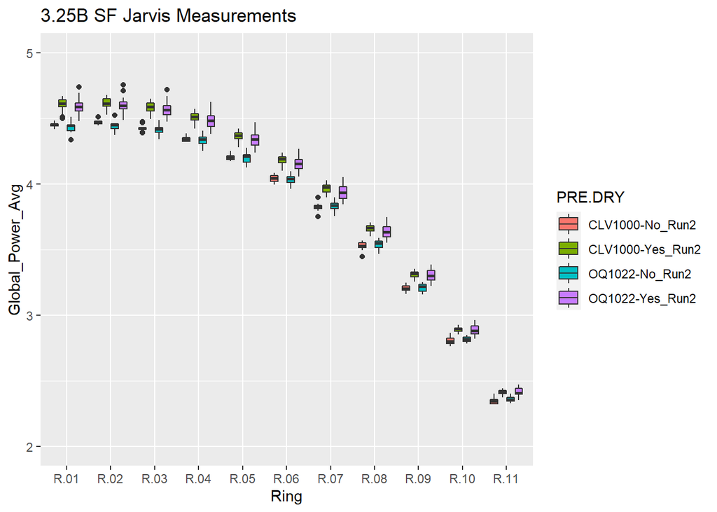

```r
##Boxplots (CLV1000) show and seperate the data more than scatter plots.

ggplot(Shark_tidy1,aes(y=Global_Power_Avg, x=Ring, fill=PRE.DRY)) + geom_boxplot() +coord_cartesian(ylim=c(2,5)) + ggtitle("3.25B SF Jarvis Measurements")
```

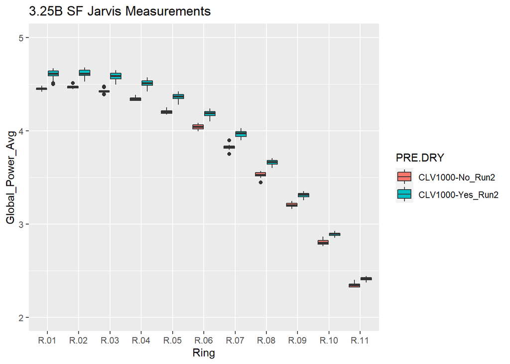

```r
Shark_tidy2<-filter(Shark.tidy,PRE.DRY=="CLV1000-Yes_Run2"|PRE.DRY=="CLV1000-No_Run2") %>% mutate(Cyl...0.06.=NULL)
ggplot(Shark_tidy2,aes(y=Global_Power_Avg, x=Ring, fill=PRE.DRY)) + geom_boxplot() +coord_cartesian(ylim=c(2,5)) + ggtitle("3.25B SF Jarvis Measurements")
```

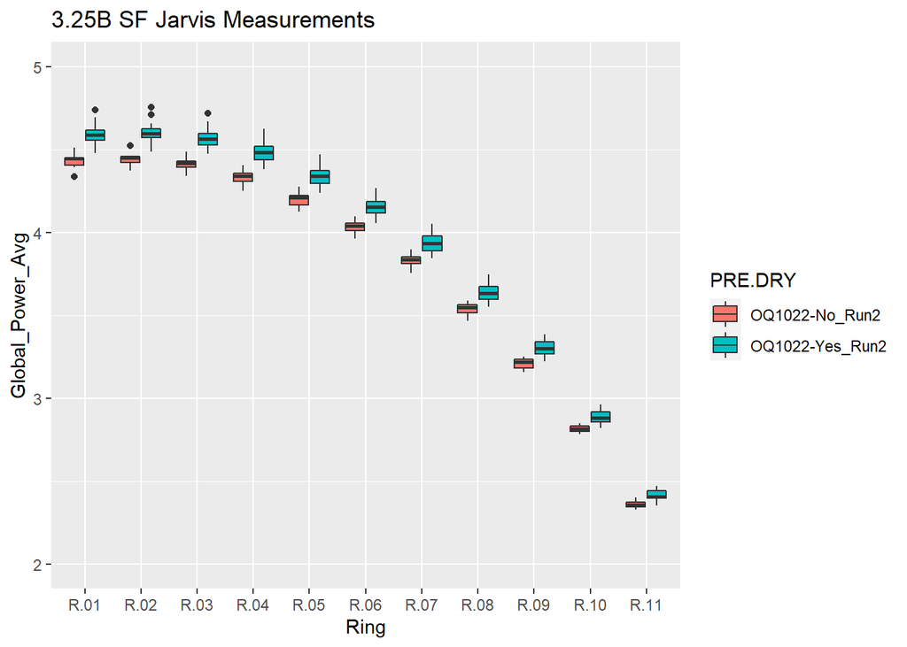

```r
## SABIC Resin grade visualization

Shark_tidy3<-filter(Shark.tidy,PRE.DRY=="OQ1022-Yes_Run2"|PRE.DRY=="OQ1022-No_Run2") %>% mutate(Cyl...0.06.=NULL)

ggplot(Shark_tidy3,aes(y=Global_Power_Avg, x=Ring, fill=PRE.DRY)) + geom_boxplot() +coord_cartesian(ylim=c(2,5)) + ggtitle("3.25B SF Jarvis Measurements")
```

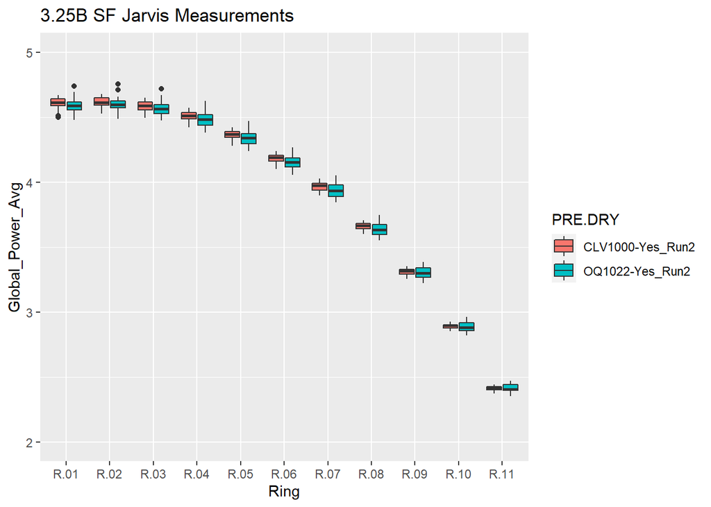

```r
## CLV1000 vs SABIC OQ1022

Shark_tidy4<-filter(Shark.tidy,PRE.DRY=="CLV1000-Yes_Run2"|PRE.DRY=="OQ1022-Yes_Run2") %>% mutate(Cyl...0.06.=NULL)
ggplot(Shark_tidy4,aes(y=Global_Power_Avg, x=Ring, fill=PRE.DRY)) + geom_boxplot() +coord_cartesian(ylim=c(2,5)) + ggtitle("3.25B SF Jarvis Measurements")
```

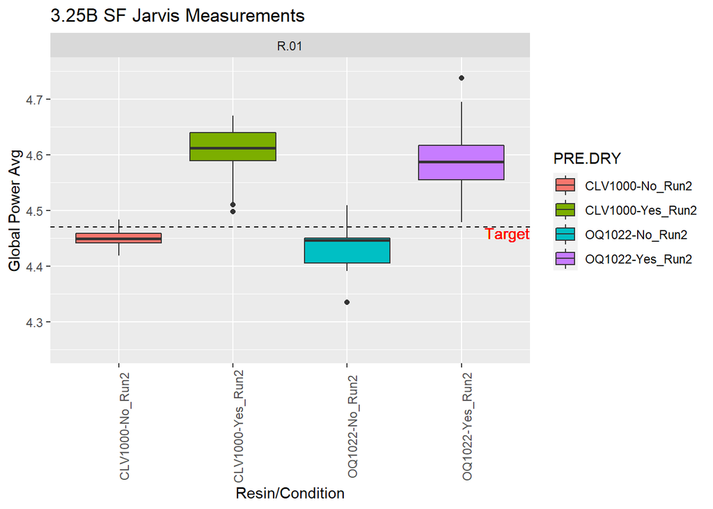

```r
## Facet Wrapping (Rings 1 & 4) to see impact of Power on Target value.

Shark.R1<-filter(Shark_tidy1, Ring=="R.01")
Shark.R2<-filter(Shark_tidy1, Ring=="R.02")
Shark.R3<-filter(Shark_tidy1, Ring=="R.03")
Shark.R4<-filter(Shark_tidy1, Ring=="R.04")
Shark.R1.R2.R3.R4<-filter(Shark_tidy1, Ring=="R.01"|Ring=="R.02"|Ring=="R.03"|Ring=="R.04")

ggplot(Shark.R1,aes(y=Global_Power_Avg, x=PRE.DRY, fill=PRE.DRY)) + geom_boxplot() +coord_cartesian(ylim=c(4.25,4.75)) + ggtitle("3.25B SF Jarvis Measurements") + facet_wrap(~Ring,nrow=1) + theme(axis.text.x = element_text(angle=90)) + labs(y="Global Power Avg", x="Resin/Condition") + geom_hline(linetype = "dashed",
             yintercept = 4.47) + geom_text(aes(label="Target", y=4.46, x=4.4 ), color="red")
```

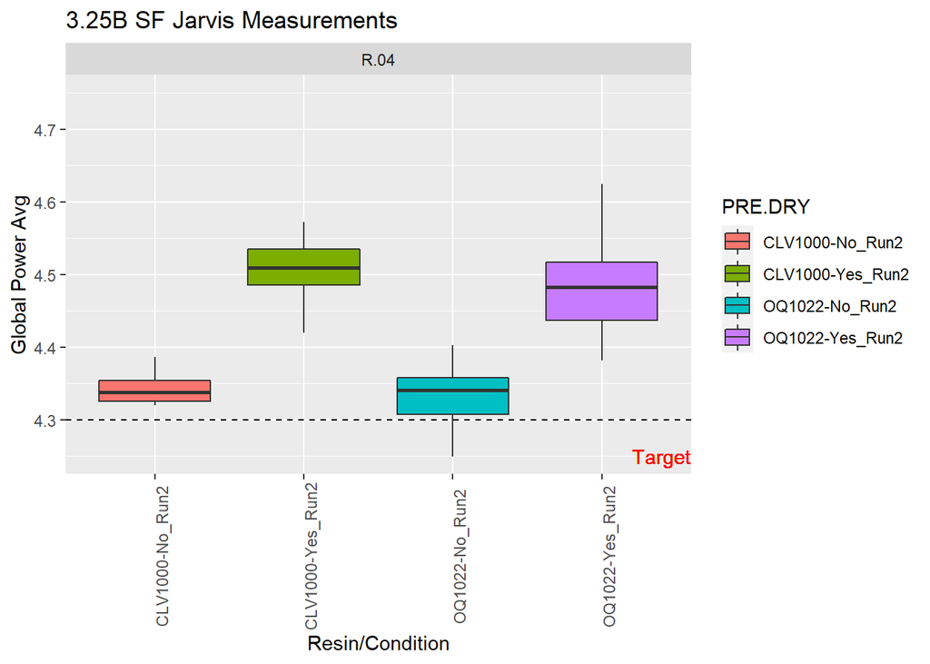

```r
ggplot(Shark.R4,aes(y=Global_Power_Avg, x=PRE.DRY, fill=PRE.DRY)) + geom_boxplot() +coord_cartesian(ylim=c(4.25,4.75)) + ggtitle("3.25B SF Jarvis Measurements") + facet_wrap(~Ring,nrow=1) + theme(axis.text.x = element_text(angle=90)) + labs(y="Global Power Avg", x="Resin/Condition") + geom_hline(linetype = "dashed",
             yintercept = 4.3) + geom_text(aes(label="Target", y=4.25, x=4.4 ), color="red")
```

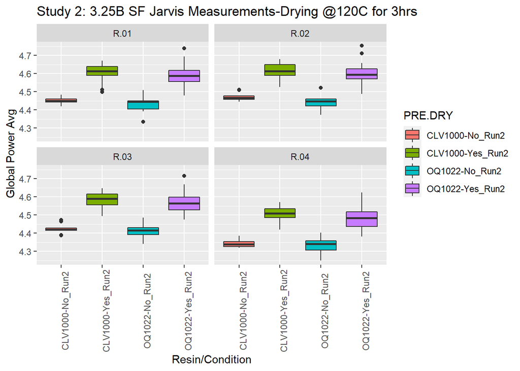

```r
ggplot(Shark.R1.R2.R3.R4,aes(y=Global_Power_Avg, x=PRE.DRY, fill=PRE.DRY)) + geom_boxplot() +coord_cartesian(ylim=c(4.25,4.75)) + ggtitle("Study 2: 3.25B SF Jarvis Measurements-Drying @120C for 3hrs") + facet_wrap(~Ring,nrow=2) + theme(axis.text.x = element_text(angle=90)) + labs(y="Global Power Avg", x="Resin/Condition")
```

## Summary:

#### Inferential statistics:

Based on the data visualization and trend analysis, a summary of key variables and observations were pursued.The table below shows a snapshot of describing the statistical summary of all Global Power avg calculations spanning rings 1 through 11. The average value described by the median for each ring was measured to get an idea of its relationship with the theoretical u-lens Power profile. Alongside the median, the standard deviation was derived from the median values to provide an understanding of the spread of the lens data. Furthermore, it is hypothesized that material conditioning has an impact on the optical global power average. The results did consistently show that the condition of PRE DRYING the material had a higher global power average across all 11 rings. Inorder to see whether this observation is true, **hypothesis testing** using the **students t-test** aswell as **ANOVA** testing was utilized. The t-test will compare the difference in means between two samples, while the ANOVA will look at all the different samples in the data(4 total).Test variables included 2 sets of questions.

- Was there a statistically significant difference between global power average for CLV1000 vs SABIC OQ1022 grades?
- Is the difference noticed between DRIED vs NON-DRIED statistically significant using alpha of 0.05?

Hypothesis testing and ANOVA using alpha(0.05) results **did not** show any discrimination between the Avg Power or Radius between the various resin grades, nor did it show that DRYING of the different grades of material made an impact on the optical results. The results were as follows:

```r
library(ggplot2)
library(dplyr)
Summary.shark<-Shark_tidy1 %>%
  group_by(PRE.DRY, Ring) %>%
  summarise(Avg_Power = median(Global_Power_Avg),
            std.dev=sd(Global_Power_Avg)) %>%
  mutate(Radius = round(591-518)/(Avg_Power-(591-518)/(167.81))) %>%
  mutate(Target = rep(c(4.47,4.52,4.5,4.43,4.3,4.11,3.87,3.58,3.23,2.83,2.37)))
Summary.shark %>%
  filter(PRE.DRY=="CLV1000-No_Run2"|PRE.DRY=="CLV1000-Yes_Run2"|PRE.DRY=="OQ1022-No_Run2"|
           PRE.DRY=="OQ1022-Yes_Run2") %>%
  slice(1:2)
```

[output not shown]

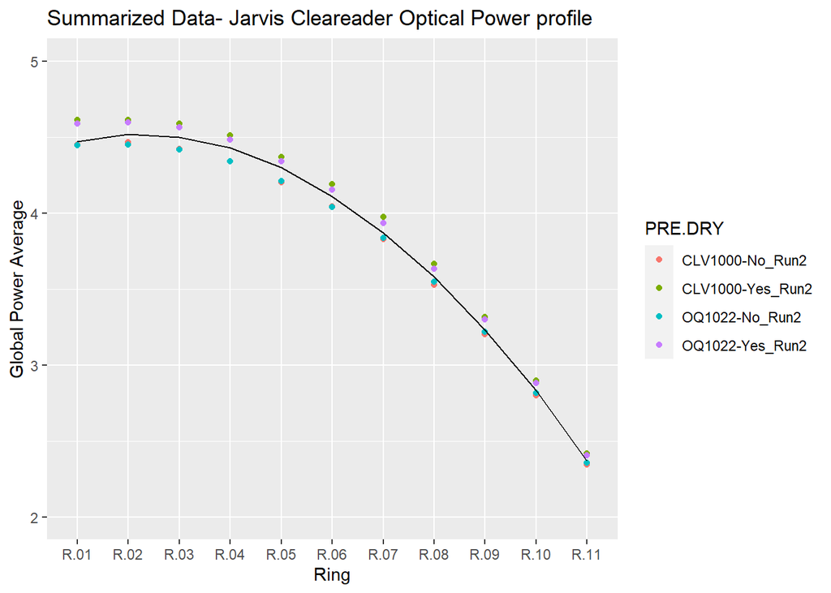

```r
## Jarvis Clear-reader optical power profile.
Shark_tidy1 %>%
  group_by(PRE.DRY, Ring) %>%
  summarise(Avg_Power = median(Global_Power_Avg),
            std.dev=sd(Global_Power_Avg)) %>%
  mutate(Radius = round(591-518)/(Avg_Power-(591-518)/(167.81))) %>%
  mutate(Target = rep(c(4.47,4.52,4.5,4.43,4.3,4.11,3.87,3.58,3.23,2.83,2.37
))) %>%
  ggplot(aes(x=Ring, y=Avg_Power, color=PRE.DRY, group=PRE.DRY)) + geom_point() +geom_line(aes(x=Ring, y=Target), color="black") + coord_cartesian(ylim=c(2,5)) + labs(y="Global Power Average") +
  ggtitle("Summarized Data- Jarvis Cleareader Optical Power profile")
```

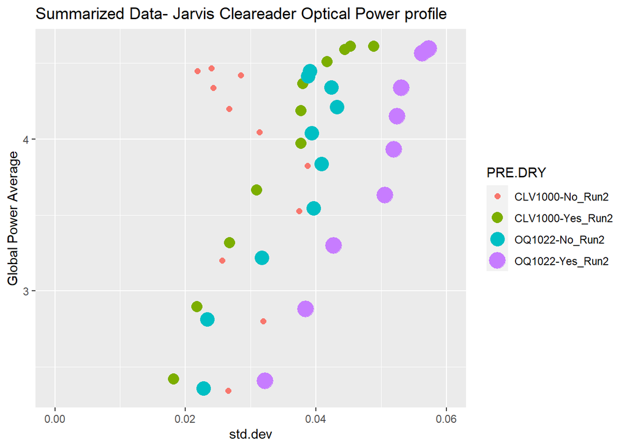

```r
## Standard deviation vs power profile
Shark_tidy1 %>%
  group_by(PRE.DRY, Ring) %>%
  summarise(Avg_Power = median(Global_Power_Avg),
            std.dev=sd(Global_Power_Avg)) %>%
  mutate(Radius = round(591-518)/(Avg_Power-(591-518)/(167.81))) %>%
  mutate(Target = rep(c(4.47,4.52,4.5,4.43,4.3,4.11,3.87,3.58,3.23,2.83,2.37
))) %>%
  ggplot(aes(x=std.dev, y=Avg_Power, color=PRE.DRY, group=PRE.DRY, size=PRE.DRY)) + geom_point() + coord_cartesian(ylim=c(2,5)) + coord_cartesian(xlim=c(0,0.06)) + labs(y="Global Power Average") +
  ggtitle("Summarized Data- Jarvis Cleareader Optical Power profile")
```

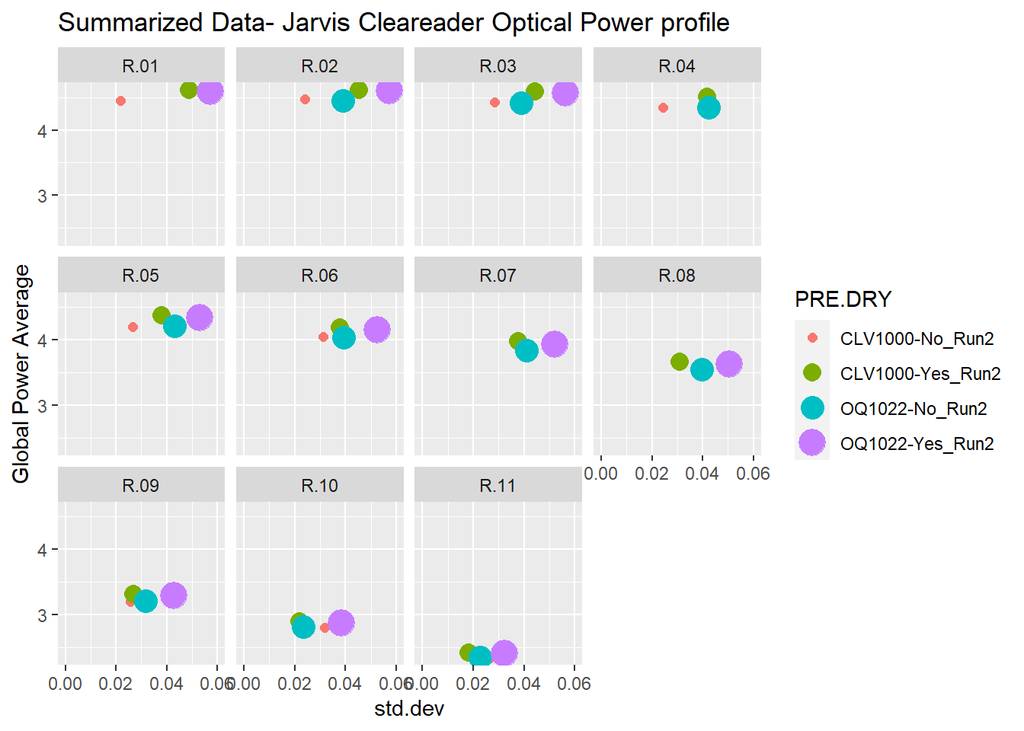

```r
## Facet wrap varied by Ring position
Shark_tidy1 %>%
  group_by(PRE.DRY, Ring) %>%
  summarise(Avg_Power = median(Global_Power_Avg),
            std.dev=sd(Global_Power_Avg)) %>%
  mutate(Radius = round(591-518)/(Avg_Power-(591-518)/(167.81))) %>%
  mutate(Target = rep(c(4.47,4.52,4.5,4.43,4.3,4.11,3.87,3.58,3.23,2.83,2.37
))) %>%
  ggplot(aes(x=std.dev, y=Avg_Power, color=PRE.DRY, group=PRE.DRY, size=PRE.DRY)) + geom_point() + coord_cartesian(ylim=c(2,5.5)) + coord_cartesian(xlim=c(0,0.06)) + labs(y="Global Power Average") +
  ggtitle("Summarized Data- Jarvis Cleareader Optical Power profile") + facet_wrap(~Ring, nrow=3)
```

```r
## Inferential Statistics- t-test
#CLV1000 vs SABIC 0Q1022
Sample.data<-Summary.shark %>%
  spread(PRE.DRY, Avg_Power)
t.test(Sample.data$`CLV1000-No_Run2`,Sample.data$`OQ1022-No_Run2`, na.action="na.pass", conf.level = 0.95)
```

```
##
##  Welch Two Sample t-test
##
## data:  Sample.data$`CLV1000-No_Run2` and Sample.data$`OQ1022-No_Run2`
## t = -0.017211, df = 19.997, p-value = 0.9864
## alternative hypothesis: true difference in means is not equal to 0
## 95 percent confidence interval:
##  -0.6498991  0.6392627
## sample estimates:
## mean of x mean of y
##  3.783182  3.788500
```

```r
#Impact of Drying on Power profile
t.test(Sample.data$`CLV1000-Yes_Run2`,Sample.data$`OQ1022-Yes_Run2`, na.action="na.pass", conf.level = 0.95)
```

```
##
##  Welch Two Sample t-test
##
## data:  Sample.data$`CLV1000-Yes_Run2` and Sample.data$`OQ1022-Yes_Run2`
## t = 0.079281, df = 19.999, p-value = 0.9376
## alternative hypothesis: true difference in means is not equal to 0
## 95 percent confidence interval:
##  -0.6477312  0.6989130
## sample estimates:
## mean of x mean of y
##  3.922682  3.897091
```

```r
t.test(Sample.data$`CLV1000-Yes_Run2`,Sample.data$`CLV1000-No_Run2`, na.action="na.pass", conf.level = 0.95)
```

```
##
##  Welch Two Sample t-test
##
## data:  Sample.data$`CLV1000-Yes_Run2` and Sample.data$`CLV1000-No_Run2`
## t = 0.43971, df = 19.967, p-value = 0.6649
## alternative hypothesis: true difference in means is not equal to 0
## 95 percent confidence interval:
##  -0.5223486  0.8013486
## sample estimates:
## mean of x mean of y
##  3.922682  3.783182
```

```r
##Inferential statistics- ANOVA.
anova(lm(Summary.shark$Avg_Power~Summary.shark$PRE.DRY))
```

|  | Df | Sum Sq | Mean Sq | F value | Pr(>F) |
| --- | --- | --- | --- | --- | --- |
| Summary.shark$PRE.DRY | 3 | 0.1730175 | 0.0576725 | 0.1050292 | 0.9566595 |
| Residuals | 40 | 21.9643582 | 0.5491090 | NA | NA |

```r
anova(lm(Summary.shark$Radius~Summary.shark$PRE.DRY))
```

|  | Df | Sum Sq | Mean Sq | F value | Pr(>F) |
| --- | --- | --- | --- | --- | --- |
| Summary.shark$PRE.DRY | 3 | 7.240658 | 2.413553 | 0.06039994 | 0.9802818 |
| Residuals | 40 | 1598.380783 | 39.959520 | NA | NA |

```r
knitr::write_bib(x = c("rmarkdown", "knitr"), file = "bib.bib")
```

# References

Shao, Zheng. Optical changes during normal emmetropization, lens-induced myopia and its recovery in the young chick eye. MS thesis. University of Waterloo, 2015.

Tarutta, Elena, et al. “Myopia: Why Study the Mechanisms of Myopia? Novel Approaches to Risk Factors Signaling Eye Growth-How Could Basic Biology Be Translated into Clinical Insights? Where Are Genetic and Proteomic Approaches Leading? How Does Visual Function Contribute to and Interact with Ametropia? Does Eye Shape Matter? Why Ametropia at All?.” Optometry and vision science 88.3 (2011): 404-447.